# Bank Client Churn Prediction

### Final Model Building

Now we will apply our parameters from previous section and train out models on full train set.

#### Logistic regression

```r
logreg <- logistic_reg(
  mode = "classification",
  engine = "glmnet",
  penalty = 0.01, mixture = 0)

w_log <- workflow() %>%
  add_recipe(rec_obj) %>%
  add_model(logreg)

final_log_model <- w_log %>%
  fit(train_data)
```

#### Random Forest model

```r
rf_model <- rand_forest(
  mode = "classification",
  engine = "ranger",
  trees = 100,
  mtry = 5,
  min_n = 200)

w_rf <- workflow() %>%
  add_recipe(rec_obj) %>%
  add_model(rf_model)

final_rf_model <- w_rf %>%
  fit(train_data)
```

#### Bosted tree model

```r
bt_model <- boost_tree(mode = "classification", engine = "xgboost",
                       trees = 100,
                       mtry = 10,
                       learn_rate = 0.174,
                       tree_depth = 11,
                       loss_reduction = 26.8,
                       sample_size = 0.949,
                       min_n = 3)
w_bt <- workflow() %>%
  add_recipe(rec_obj) %>%
  add_model(bt_model)

final_bt_model <- w_bt %>%
  fit(train_data)
```

#### Knn model

KNN is a supervised learning algorithm that predicts the output of the data points using a labeled input data set. One of the simplest machine learning algorithms, it can be used to solve a wide range of issues. It primarily relies on similarity of features.

```r
knn_model <- nearest_neighbor(mode = "classification",
                              neighbors = 150,
                              engine = "kknn")
w_knn <- workflow() %>%
  add_recipe(rec_obj) %>%
  add_model(knn_model)


final_knn_model <- w_knn %>%
  fit(train_data)
```

### Test set predictions

In this section we well evaluate how our models performed on the test set.

#### Logistic regression

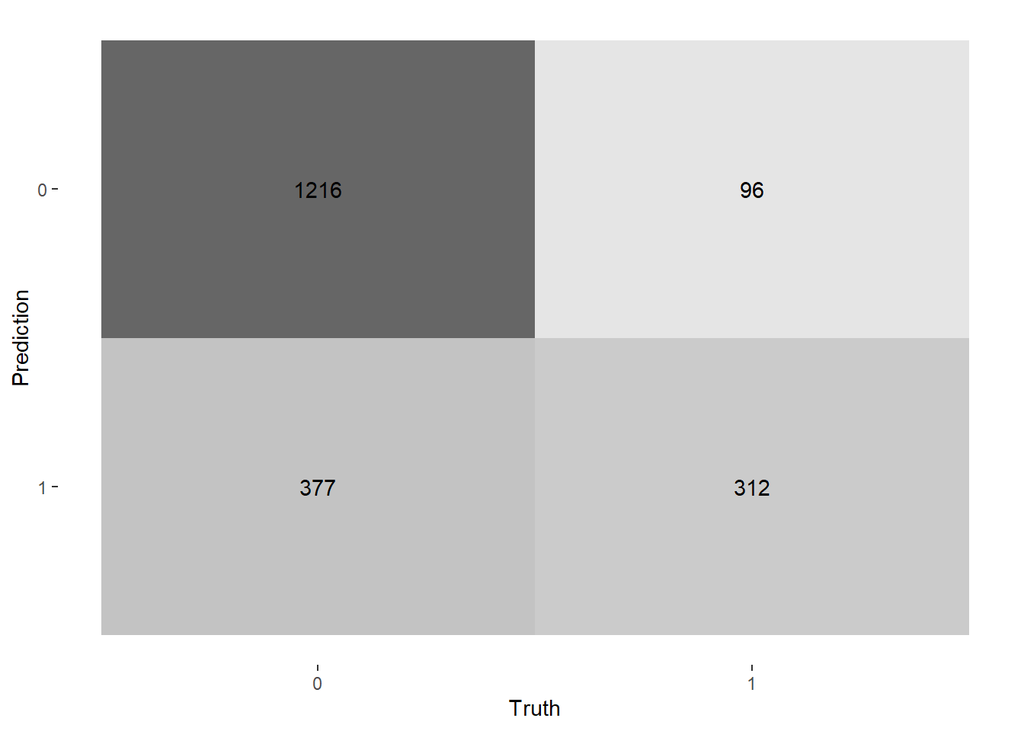

```r
pred <- augment(final_log_model, test_data)
test_data %>%
  mutate(prediction = pred$.pred_class) %>%
  conf_mat(churn, prediction) %>%
  autoplot(type = "heatmap")
```

```r
TP<-1220
FP<-115
TN<-293
FN<-373
accuracy<-(TP+TN)/(TP+FP+TN+FN)
round(accuracy,4)
```

```
## [1] 0.7561
```